# Case Study 12 - Classifying the Higgs Boson with Neural Networks

Ivelin Angelov, Yao Yao, Brian Kruse

MSDS 7333 Section 402

August 6, 2018

## Methods

The first 10,500,000 rows are trained and validated with a 9:1 ratio and the last 500,000 rows are tested for F1, accuracy, precision, recall, and ROC score metrics. The parameters optimized are number of layers, number of neurons, activation function, batch size, kernel initializer, optimizer, learning rate, epsilon, decay rate, and dropout rate. With these optimized parameters, the final model expands the number of default epochs from 20 to 500 with early stopping to find the highest ROC score.

The steps used for this analysis are: 1) load and reduce the dataset to float16 to reduce memory consumption; 2) explore the distribution of each variable by label; 3) split the dataset into training, validation, and testing; 4) optimize parameters individually; 5) use the optimized parameters for the final model with 500 epochs and early stopping to achieve highest ROC score [3].

Note: The seed value is consistent for reproducible results during the runtime session but may still give different results when trained on CPU versus GPU [4].

```python
%matplotlib inline

import sys
try:
    sys.getwindowsversion()
except AttributeError:
    isWindows = False
else:
    isWindows = True
if isWindows:
    import win32api,win32process,win32con
    pid = win32api.GetCurrentProcessId()
    handle = win32api.OpenProcess(win32con.PROCESS_ALL_ACCESS, True, pid)
    win32process.SetPriorityClass(handle, win32process.ABOVE_NORMAL_PRIORITY_CLASS)
import warnings
warnings.filterwarnings('ignore')

from keras.models import Sequential
from keras.layers.core import Dense, Dropout, Activation
from keras.optimizers import SGD
import keras
from pprint import pprint
import seaborn as sns
import pandas as pd
import numpy as np
import matplotlib.pyplot as plt
from sklearn import metrics
from sklearn.metrics import roc_auc_score

# in order to have reproducible result
from numpy.random import seed
from tensorflow import set_random_seed
seed(2)
set_random_seed(2)
```

The get_metrics function retrieves the current model's ROC, accuracy, precision, recall, and F1-score metrics for the test dataset.

The net function sets default parameters for a neural network if those parameters are left undefined. For the default neural network parameters, dropout is 0.1, activations is relu, initializer is uniform, optimizer is stochastic gradient descent, learning rate is 0.1, learning decay is 1e-6, momentum is 0.9, Nesterov method is applied, batch size is 5000, patience is 2, where accuracy and binary cross entropy loss functions are monitored for both training and validation datasets.

The train function sets those parameters with early stopping to find accuracy and validation accuracy of the current neural network per epoch for both training and validation datasets.

```python
def get_metrics(y_true, y_pred, treshhold=.5):
    RocAuc=metrics.roc_auc_score(y_test, y_pred)
    y_pred = (y_pred > treshhold).astype(np.int32)
    return dict(
        RocAuc="{:.4f}".format(metrics.roc_auc_score(y_test, y_pred)),
        Accuracy="{:.4f}".format(metrics.accuracy_score(y_test, y_pred)),
        Precision="{:.4f}".format(metrics.precision_score(y_test, y_pred)),
        Recall="{:.4f}".format(metrics.recall_score(y_test, y_pred)),
        F1="{:.4f}".format(metrics.f1_score(y_test, y_pred))
    )

def net(units,
        dropouts=.1,
        activations=None,
        kernel_initializers='uniform',
        optimizer=None
    ):

    input_dim = x.shape[1]
    assert type(units) == list and len(units) and units[-1] == 1
    units = units[:]
    if activations == None:
        activations = ['relu' for _ in units]
        activations[-1] = 'sigmoid'
    activations = activations[:]
    if type(dropouts) != list:
        dropouts = [dropouts for _ in range(len(units)-1)]
    dropouts = dropouts[:]
    if type(kernel_initializers) != list:
        kernel_initializers = [kernel_initializers for _ in units]
    kernel_initializers = kernel_initializers[:]
    assert len(units) == len(kernel_initializers) == len(activations) == len(dropouts)+1
    if optimizer is None:
        optimizer = SGD(lr=0.1, decay=1e-6, momentum=0.9, nesterov=True)

    model = Sequential()

    # first layer is special so it is out of the loop
    unit = units.pop(0)
    activation = activations.pop(0)
    try:
        dropout = dropouts.pop(0)
    except:
        dropout = 0.
    kernel_initializer = kernel_initializers.pop(0)

    model.add(Dense(unit, input_dim=input_dim, kernel_initializer=kernel_initializer))
    if activation:
        model.add(Activation(activation))
    if dropout:
        model.add(Dropout(dropout))

    for unit in units:
        activation = activations.pop(0)
        try:
            dropout = dropouts.pop(0)
        except:
            dropout = 0.
        kernel_initializer = kernel_initializers.pop(0)

        model.add(Dense(unit, kernel_initializer=kernel_initializer))
        if activation:
            model.add(Activation(activation))
        if dropout:
            model.add(Dropout(dropout))

    model.compile(loss='binary_crossentropy', metrics=['accuracy'], optimizer=optimizer)
    return model

default_epochs = 20

def train(model, epochs=default_epochs, batch_size=5000, checkpoint=False, patience=2):
    history = keras.callbacks.History()
    early_stop = keras.callbacks.EarlyStopping(
        monitor='val_loss',
        min_delta=0,
        patience=patience,
        verbose=0,
        mode='auto')

    callbacks = [history, early_stop]

    if checkpoint:
        filepath="weights.best.hdf5"
        checkpoint = keras.callbacks.ModelCheckpoint(
            filepath='best.h5', monitor='val_acc', verbose=1, save_best_only=True, mode='max')
      #  callbacks.append(checkpoint)

    model.fit(x, y, epochs=epochs, batch_size=batch_size, callbacks=callbacks, validation_split=.1)
    result = pd.DataFrame(history.history)
    del result['loss']
    del result['val_loss']
    result = result.rename(columns={
        'acc': 'Train Accuracy',
        'val_acc': 'Validation Accuracy',
        #'loss': 'Train Loss',
        #'val_loss': 'Validation Loss',
    })
    index = pd.Index(np.arange(epochs), name='Epoch')
    result.reindex(index)
    result.index += 1
    result.index.name = 'Epoch'
    result.columns.name = 'Accuracy'
    return result
```

## Results

### Exploratory Analysis

Due to the size of the dataset, it is first imported as float64 and then reduced to float16 to lower memory usage to 608.4 MB. Table 1 shows how float16 still perserves data integrity compared to that of float64. Freeing up more memory saves processing speed and allocation for the rest of the neural network parameter optimization.

```python
# !wget https://archive.ics.uci.edu/ml/machine-learning-databases/00280/HIGGS.csv.gz
# !gunzip *.gz

data=pd.read_csv("HIGGS.csv",header=None, dtype=np.float64, engine='c')
data.columns=['label','lepton pt','lepton eta','lepton phi','missing energy magnitude','missing energy phi',
              'jet 1 pt','jet 1 eta','jet 1 phi','jet 1 b-tag','jet 2 pt','jet 2 eta','jet 2 phi','jet 2 b-tag',
              'jet 3 pt','jet 3 eta','jet 3 phi','jet 3 b-tag','jet 4 pt','jet 4 eta','jet 4 phi','jet 4 b-tag',
              'm_jj','m_jjj','m_lv','m_jlv','m_bb','m_wbb','m_wwbb']

data1 = data.max()-data.min()
data=data.astype('float16')
data.info()
```

```
<class 'pandas.core.frame.DataFrame'>
RangeIndex: 11000000 entries, 0 to 10999999
Data columns (total 29 columns):
label                       float16
lepton pt                   float16
lepton eta                  float16
lepton phi                  float16
missing energy magnitude    float16
missing energy phi          float16
jet 1 pt                    float16
jet 1 eta                   float16
jet 1 phi                   float16
jet 1 b-tag                 float16
jet 2 pt                    float16
jet 2 eta                   float16
jet 2 phi                   float16
jet 2 b-tag                 float16
jet 3 pt                    float16
jet 3 eta                   float16
jet 3 phi                   float16
jet 3 b-tag                 float16
jet 4 pt                    float16
jet 4 eta                   float16
jet 4 phi                   float16
jet 4 b-tag                 float16
m_jj                        float16
m_jjj                       float16
m_lv                        float16
m_jlv                       float16
m_bb                        float16
m_wbb                       float16
m_wwbb                      float16
dtypes: float16(29)
memory usage: 608.4 MB
```

```python
data2 = data.max()-data.min()

memory = pd.concat([data1, data2], axis=1, join_axes=[data1.index])
memory.columns=['Before','After']
print('Table 1: Data Min and Max from Float64 to Float16')
memory
```

```
Table 1: Data Min and Max from Float64 to Float16
```

|  | Before | After |
| --- | --- | --- |
| label | 1.000000 | 1.000000 |
| lepton pt | 11.824217 | 11.828125 |
| lepton eta | 4.869844 | 4.871094 |
| lepton phi | 3.485744 | 3.484375 |
| missing energy magnitude | 15.396584 | 15.398438 |
| missing energy phi | 3.487201 | 3.488281 |
| jet 1 pt | 9.802888 | 9.796875 |
| jet 1 eta | 5.939399 | 5.937500 |
| jet 1 phi | 3.482691 | 3.482422 |
| jet 1 b-tag | 2.173076 | 2.173828 |
| jet 2 pt | 11.458100 | 11.460938 |
| jet 2 eta | 5.826299 | 5.828125 |
| jet 2 phi | 3.485546 | 3.484375 |
| jet 2 b-tag | 2.214872 | 2.214844 |
| jet 3 pt | 14.445382 | 14.445312 |
| jet 3 eta | 5.459672 | 5.460938 |
| jet 3 phi | 3.484953 | 3.484375 |
| jet 3 b-tag | 2.548224 | 2.548828 |
| jet 4 pt | 12.517213 | 12.515625 |
| jet 4 eta | 4.995274 | 4.996094 |
| jet 4 phi | 3.486063 | 3.486328 |
| jet 4 b-tag | 3.101961 | 3.101562 |
| m_jj | 40.117297 | 40.125000 |
| m_jjj | 20.174106 | 20.171875 |
| m_lv | 7.909691 | 7.910156 |
| m_jlv | 14.130433 | 14.132812 |
| m_bb | 17.714990 | 17.718750 |
| m_wbb | 11.201410 | 11.203125 |
| m_wwbb | 8.043777 | 8.046875 |

#### Table 1: Float16 still perserves data integrity compared to that of float64

28 variables are plotted by label to show how some distributions are numerical categorical, some have uniform distributions, some have normal distributions, and others have skewed distributions [Figure 1 to 28]. No variable transformations are conducted prior to the neural network training and modeling. The goal is to see how neural networks perform on the original dataset to predict Higgs Boson label.

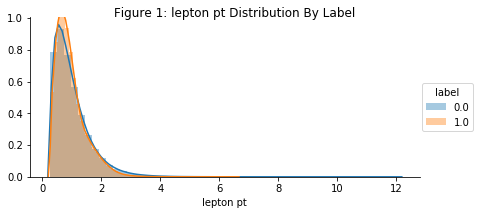

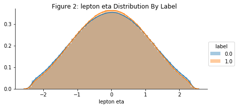

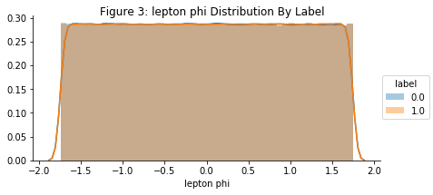

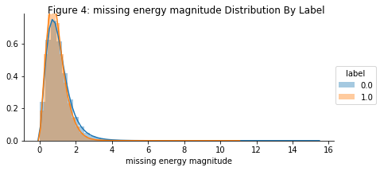

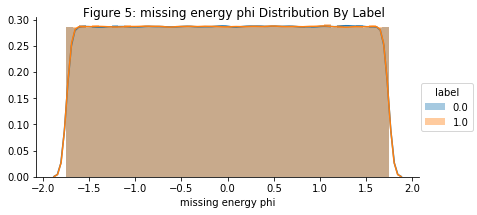

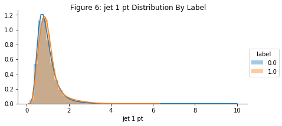

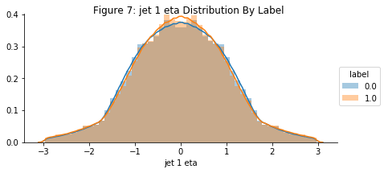

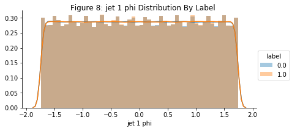

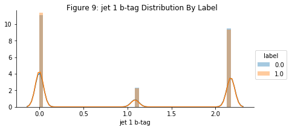

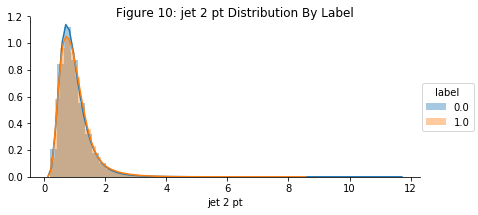

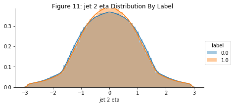

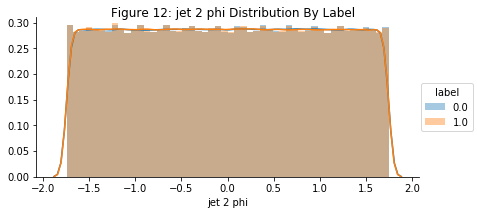

[16 more figures not shown]

```python
plt.rcParams['figure.max_open_warning']=40
colnames=list(data.columns.values)
for i in colnames[1:]:
    facet = sns.FacetGrid(data, hue='label',aspect=2).set_titles(i)
    facet.map(sns.distplot,i)
    facet.add_legend()
    Title=str(["Figure ",colnames.index(i),": ",i," Distribution By Label"])
    facet.fig.suptitle(''.join(map(str, list(["Figure ",colnames.index(i),": ",i," Distribution By Label"]))))
    plt.show()
```

#### Figure 1 to 28: Some distributions are numerical categorical, some have uniform distributions, some have normal distributions, and others have skewed distributions

Direct heatmap of correlations show that variables are weakly correlated with the Higgs Boson label and that the last 7 derivative kinematic variables are correlated with each other [Figure 29].

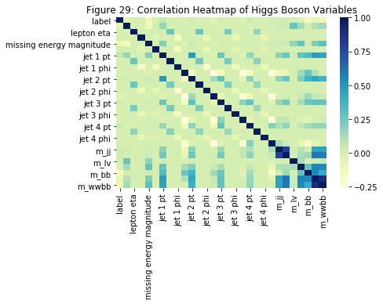

```python
ax = plt.axes()
sns.heatmap(data.corr(), cmap="YlGnBu", ax = ax)
ax.set_title('Figure 29: Correlation Heatmap of Higgs Boson Variables')
plt.show()
```

#### Figure 29: Variables are weakly correlated with the Higgs Boson label and the last 7 derivative kinematic variables are correlated with each other

The training and test datasets are further split into their target and predictor variables y and x, respectively. The target variable is almost perfectly balanced to 0.5 so that we can choose accuracy as a target metric.

```python
# labels must be 0 or 1 and not in between
assert not ((data["label"]>0)&(data["label"]<1)).sum()
data["label"] = data["label"].astype(np.int16)

test_data = data.iloc[-500000:].copy()
data = data.iloc[:-500000]

y = np.array(data.iloc[:,0])
x = np.array(data.iloc[:,1:])

x_test = np.array(test_data.iloc[:,1:])
y_test = np.array(test_data.iloc[:,0])

del test_data, data
y.mean()
```

```
0.5299634285714285
```

The baseline metrics of a neural network with 1 layer and 1 neurode shows that ROC accuracy, accuracy, and precision are around 0.5 while recall is very high, which influences F1-Score.

```python
model = net([1])
print("Test Dataset :", get_metrics(y_test, model.predict(x_test)))
```

```
WARNING:tensorflow:From /home/evo/.local/lib/python3.5/site-packages/keras/backend/tensorflow_backend.py:1290: calling reduce_mean (from tensorflow.python.ops.math_ops) with keep_dims is deprecated and will be removed in a future version.
Instructions for updating:
keep_dims is deprecated, use keepdims instead
Test Dataset : {'Precision': '0.5288', 'RocAuc': '0.4997', 'Accuracy': '0.5238', 'Recall': '0.9160', 'F1': '0.6705'}
```

### 1. Pick 3 or more different architectures (add/subtract layers + neurons) and run the model + score.

#### Number of layers search

When optimizing for layers, the default activation is relu for classification because sigmoid and tanh have vanishing gradients that do not work as well on deeper networks as relu or elu. 50 neurons are used when optimizing for layers.

```python
hparams = []
for layers in range(1,5):
    hparams.append(
        dict(units=[50]*layers+[1])
    )
print('Testing Hyperparameters:')
pprint(hparams)

trainAcc_layers = {}
valAcc_layers = {}

for hparam in hparams:
    title = "Hyper Params: %s" % str(hparam)
    print(title)
    model = net(**hparam)
    result = train(model)
    trainAcc_layers[title] = result['Train Accuracy']
    valAcc_layers[title] = result['Validation Accuracy']
    print("Test Dataset :", get_metrics(y_test, model.predict(x_test)))
```

```
Testing Hyperparameters:
[{'units': [50, 1]},
 {'units': [50, 50, 1]},
 {'units': [50, 50, 50, 1]},
 {'units': [50, 50, 50, 50, 1]}]
Hyper Params: {'units': [50, 1]}
WARNING:tensorflow:Variable *= will be deprecated. Use variable.assign_mul if you want assignment to the variable value or 'x = x * y' if you want a new python Tensor object.
Train on 9450000 samples, validate on 1050000 samples
Test Dataset : {'Precision': '0.7183', 'RocAuc': '0.7221', 'Accuracy': '0.7263', 'Recall': '0.7941', 'F1': '0.7543'}
Hyper Params: {'units': [50, 50, 1]}
Train on 9450000 samples, validate on 1050000 samples
Test Dataset : {'Precision': '0.7421', 'RocAuc': '0.7432', 'Accuracy': '0.7464', 'Recall': '0.7979', 'F1': '0.7690'}
Hyper Params: {'units': [50, 50, 50, 1]}
Train on 9450000 samples, validate on 1050000 samples
Test Dataset : {'Precision': '0.7567', 'RocAuc': '0.7500', 'Accuracy': '0.7519', 'Recall': '0.7828', 'F1': '0.7695'}
Hyper Params: {'units': [50, 50, 50, 50, 1]}
Train on 9450000 samples, validate on 1050000 samples
```

#### Layers search result

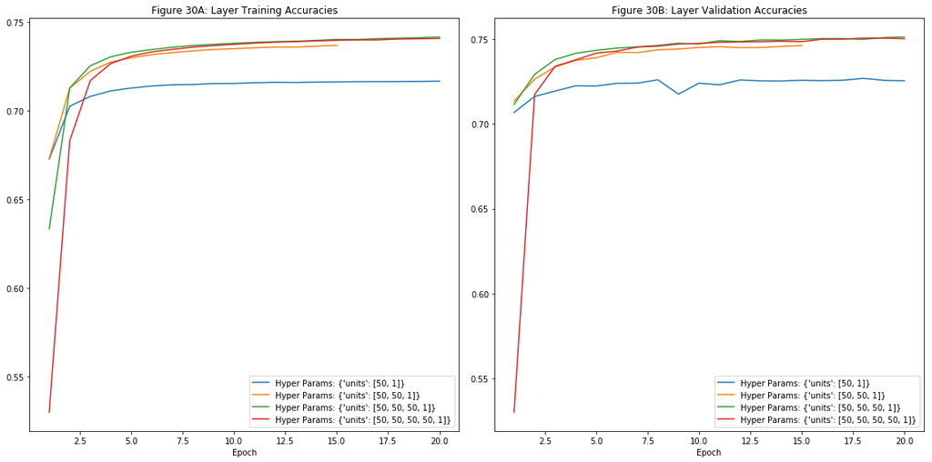

```python
fig, axes = plt.subplots(nrows=1, ncols=2, figsize=(16,8))

pd.DataFrame(trainAcc_layers).plot(title='Figure 30A: Layer Training Accuracies', ax=axes[0])
pd.DataFrame(valAcc_layers).plot(title='Figure 30B: Layer Validation Accuracies', ax=axes[1])
plt.tight_layout()
```

#### Figure 30: The best number of layers is 3 with a training set accuracy of 0.7417 and a validation accuracy of 0.7512.

```python
best_n_layers = 3
```

#### Number of neurons search

Using three layers, the number of neurons are increased for each layer. For simplicity, each layer increased by the same number of neurons to optimize for accuracy and F1-score.

```python
hparams = []

for units in [100, 200, 400, 800]:
    hparams.append(
        dict(units=[units]*best_n_layers+[1])
    )

print('Testing Hyperparameters:')
pprint(hparams)

trainAcc_dense = {}
valAcc_dense = {}

for hparam in hparams:
    title = "Hyperparameters: %s" % str(hparam)
    print(title)

    model = net(**hparam)
    result = train(model, epochs=5)
    trainAcc_dense[title] = result['Train Accuracy']
    valAcc_dense[title] = result['Validation Accuracy']
    print("Test Dataset :", get_metrics(y_test, model.predict(x_test)))
```

#### Number of neurons search result

Accuracy and F1-score are the highest at 800 neurons per layer with training set accuracy of 0.76 and a validation accuracy of 0.765 [Figure 31]. Time spent to run each epoch significantly increased when neurons are increased. Due to time and processing restraints, the best number of neurons is still 800 yet set to 100 neurons in order to save time to optimize for the rest of the parameters until the final model.

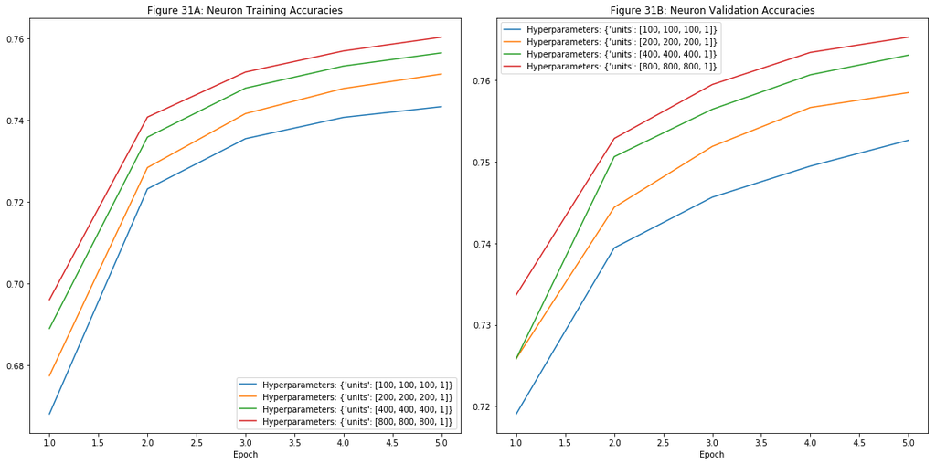

```python
fig, axes = plt.subplots(nrows=1, ncols=2, figsize=(16,8))

pd.DataFrame(trainAcc_dense).plot(title='Figure 31A: Neuron Training Accuracies', ax=axes[0])
pd.DataFrame(valAcc_dense).plot(title='Figure 31B: Neuron Validation Accuracies', ax=axes[1])
plt.tight_layout()
```

#### Figure 31: The best number of neurons is 800 per layer with a training set accuracy of 0.76 and a validation accuracy of 0.765.

```python
#still 800, reduced to 100 to save time and processing
best_n_units = 100
```

### 2. With those same 3 architectures, run the SAME architecture but with 2 different (from sigmoid) activation functions.

#### Activations Search

When optimizing for activations, the default activation is relu for classification because sigmoid and tanh have vanishing gradients that do not work as well on deeper networks as relu or elu.

```python
hparams = []
for activation in ['elu', 'relu', 'selu']:
    hparams.append(
        dict(
            units=[best_n_units]*best_n_layers+[1],
            activations=[activation]*best_n_layers+['sigmoid'],
        )
    )

print('Testing Hyperparameters:')
pprint(hparams)

trainAcc_activation = {}
valAcc_activation = {}

for hparam in hparams:
    title = "Hyperparameters: %s" % str(hparam)
    print(title)
    model = net(**hparam)
    result = train(model, epochs=5)
    trainAcc_activation[title] = result['Train Accuracy']
    valAcc_activation[title] = result['Validation Accuracy']
    print("Test Dataset :", get_metrics(y_test, model.predict(x_test)))
```

#### Activations Search Result

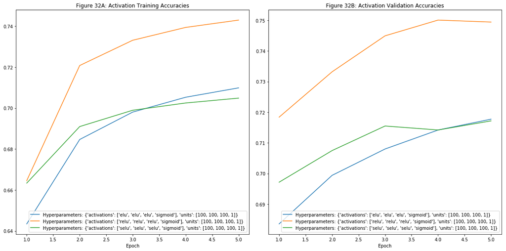

```python
fig, axes = plt.subplots(nrows=1, ncols=2, figsize=(16,8))

pd.DataFrame(trainAcc_activation).plot(title='Figure 32A: Activation Training Accuracies', ax=axes[0])
pd.DataFrame(valAcc_activation).plot(title='Figure 32B: Activation Validation Accuracies', ax=axes[1])
plt.tight_layout()
```

```python
best_activation = 'relu'
```

### 3. Take your best model from parts 1&2 and vary the batch size by at least 2 orders of magnitude

#### Batch Size Search

Batch sizes range from 500 to 50000 to find the best validation accuracy.

```python
best_hparam = dict(
    units=[best_n_units]*best_n_layers+[1],
    activations=[best_activation]*best_n_layers+['sigmoid'],
)

trainAcc_batch = {}
valAcc_batch = {}

for batch_size in 500, 1000, 50000:
    title = "Batch Size: %d" % batch_size
    print(title)
    model = net(**best_hparam)
    result = train(model, batch_size=batch_size, epochs=10)
    trainAcc_batch[title] = result['Train Accuracy']
    valAcc_batch[title] = result['Validation Accuracy']
    print("Test Dataset :", get_metrics(y_test, model.predict(x_test)))
```

#### Batch Size Search Result

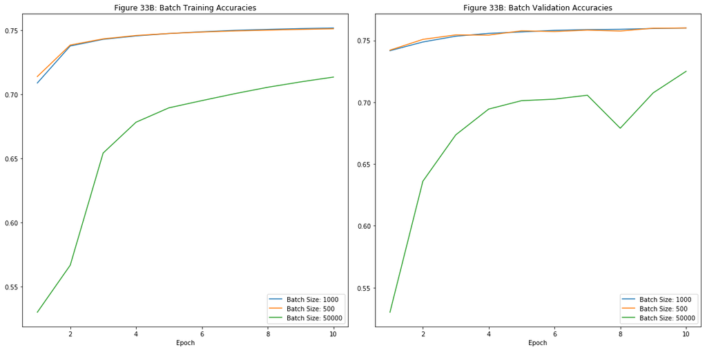

```python
fig, axes = plt.subplots(nrows=1, ncols=2, figsize=(16,8))

pd.DataFrame(trainAcc_batch).plot(title='Figure 33B: Batch Training Accuracies', ax=axes[0])
pd.DataFrame(valAcc_batch).plot(title='Figure 33B: Batch Validation Accuracies', ax=axes[1])
plt.tight_layout()
```

```python
best_batch_size = 1000
```

### 4. Take your best model (score) from parts 1&2 and use 3 different kernel initializers. Use a reasonable batch size.

#### Kernel Initializer Search

Initializers for classification perform better with normal distributions rather than uniform distributions because the separation is needed to distinguish the difference. Therefore, only initialiers with normal distributions are used as well as variance scaling and orthogonal.

```python
best_hparam = dict(
    units=[best_n_units]*best_n_layers+[1],
    activations=[best_activation]*best_n_layers+['sigmoid'],
)

trainAcc_initial = {}
valAcc_initial = {}

for kernel_initializer in ['VarianceScaling','orthogonal','random_normal','truncated_normal',
                           'glorot_normal','lecun_normal','he_normal']:
    title = "Kernel Initializers: %s" % kernel_initializer
    best_hparam['kernel_initializers'] = kernel_initializer
    print(title)

    model = net(**best_hparam)
    result = train(model, batch_size=best_batch_size, epochs=10)
    trainAcc_initial[title] = result['Train Accuracy']
    valAcc_initial[title] = result['Validation Accuracy']
    print("Test Dataset :", get_metrics(y_test, model.predict(x_test)))
```

#### Kernel Initializer Search Result

The random normal initializer is the best with a training accuracy of 0.752 and a validation accuracy of 0.761 [Figure 34].

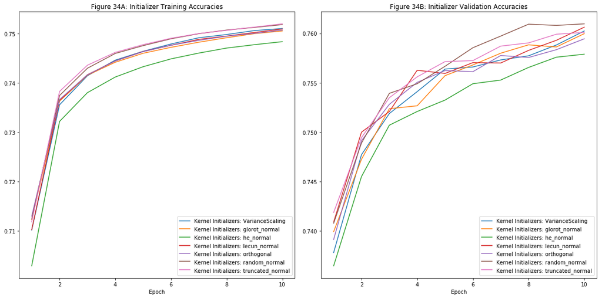

```python
fig, axes = plt.subplots(nrows=1, ncols=2, figsize=(16,8))

pd.DataFrame(trainAcc_initial).plot(title='Figure 34A: Initializer Training Accuracies', ax=axes[0])
pd.DataFrame(valAcc_initial).plot(title='Figure 34B: Initializer Validation Accuracies', ax=axes[1])
plt.tight_layout()
```

#### Figure 34: The random normal initializer is the best with a training accuracy of 0.752 and a validation accuracy of 0.761

```python
best_kernel_initializer = 'random_normal'
```

### 5. Take your best results from #3 and try 3 different optimizers.

#### Optimizers Search

Optimizers are compared using their default learning rates and parameters because each algorithm are optimized differently.

```python
hparam = dict(
    units=[best_n_units]*best_n_layers+[1],
    activations=[best_activation]*best_n_layers+['sigmoid'],
    kernel_initializers=best_kernel_initializer
)

optimizers = dict(
    SGD=keras.optimizers.SGD(lr=.01, momentum=0.9, nesterov=True),
    Adagrad=keras.optimizers.Adagrad(),
    Adamax=keras.optimizers.Adamax(),
    Nadam=keras.optimizers.Nadam(),
    RMSprop=keras.optimizers.RMSprop(),
    Adadelta=keras.optimizers.Adadelta()
)

trainAcc_optimizer = {}
valAcc_optimizer = {}

for optimizer_name in optimizers:
    title = "Optimizer: %s" % optimizer_name
    print(optimizer_name)

    model = net(**hparam, optimizer=optimizers[optimizer_name])
    result = train(model, batch_size=best_batch_size, epochs=10)
    trainAcc_optimizer[title] = result['Train Accuracy']
    valAcc_optimizer[title] = result['Validation Accuracy']
    print("Test Dataset :", get_metrics(y_test, model.predict(x_test)))
```

#### Optimizers Search Result

The optimizer Adamax is the best with a training accuracy of 0.752 and a valication accuracy of 0.761 [Figure 35].

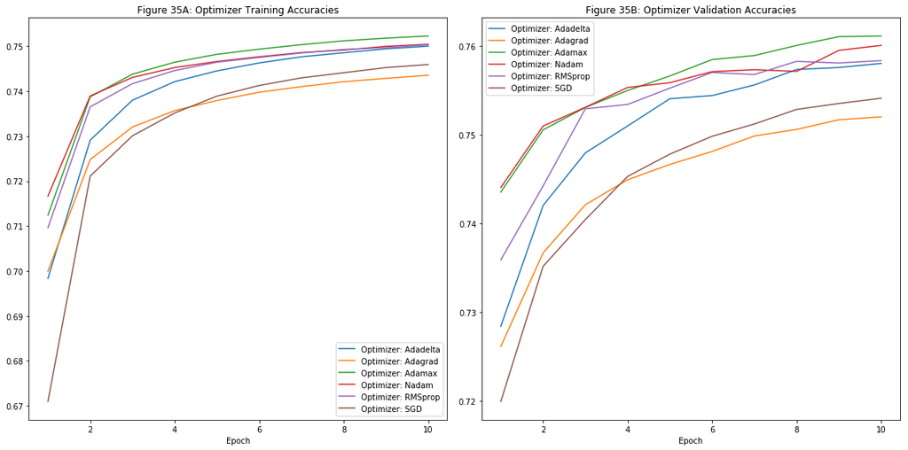

```python
fig, axes = plt.subplots(nrows=1, ncols=2, figsize=(16,8))

pd.DataFrame(trainAcc_optimizer).plot(title='Figure 35A: Optimizer Training Accuracies', ax=axes[0])
pd.DataFrame(valAcc_optimizer).plot(title='Figure 35B: Optimizer Validation Accuracies', ax=axes[1])
plt.tight_layout()
```

#### Figure 35: The optimizer Adamax is the best with a training accuracy of 0.752 and a valication accuracy of 0.761

### 6. Take all that you’ve learned so far and give your best shot at producing a score.

#### Learning Rate Search

The default learning rate of 0.002 is altered to see if validation accuracy is improved.

```python
hparam = dict(
    units=[best_n_units]*best_n_layers+[1],
    activations=[best_activation]*best_n_layers+['sigmoid'],
    kernel_initializers=best_kernel_initializer
)

optimizers = dict(
    Adamaxlr0015=keras.optimizers.Adamax(lr=0.0015),
    Adamaxlr=keras.optimizers.Adamax(),
    Adamaxlr0025=keras.optimizers.Adamax(lr=0.0025),
)

trainAcc_lr = {}
valAcc_lr = {}

for optimizer_name in optimizers:
    title = "Optimizer: %s" % optimizer_name
    print(optimizer_name)

    model = net(**hparam, optimizer=optimizers[optimizer_name])
    result = train(model, batch_size=best_batch_size, epochs=5)
    trainAcc_lr[title] = result['Train Accuracy']
    valAcc_lr[title] = result['Validation Accuracy']
    print("Test Dataset :", get_metrics(y_test, model.predict(x_test)))
```

#### Learning Rate Search Results

The default learning rate of 0.002 is the best with a training accuracy of 0.747 and a validation accuracy of 0.7570 [Figure 36].

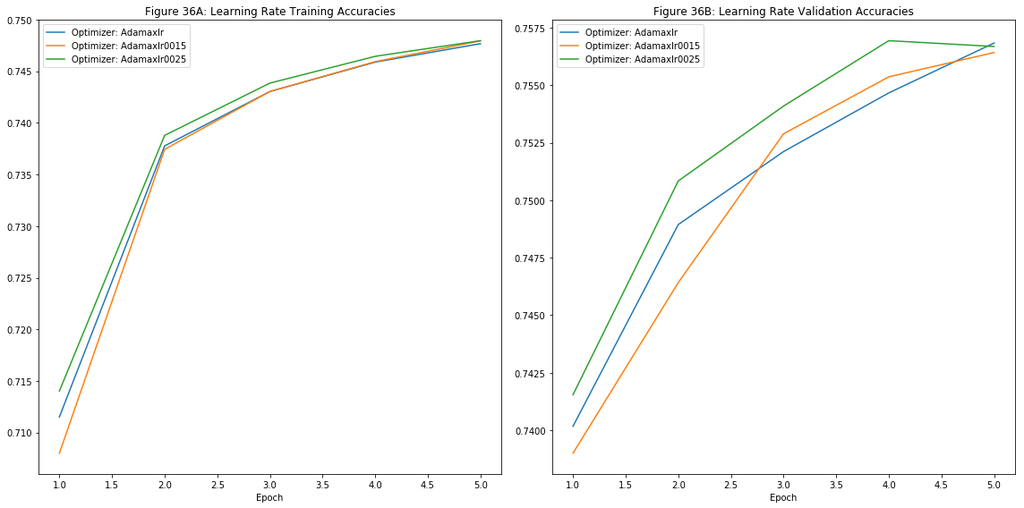

```python
fig, axes = plt.subplots(nrows=1, ncols=2, figsize=(16,8))

pd.DataFrame(trainAcc_lr).plot(title='Figure 36A: Learning Rate Training Accuracies', ax=axes[0])
pd.DataFrame(valAcc_lr).plot(title='Figure 36B: Learning Rate Validation Accuracies', ax=axes[1])
plt.tight_layout()
```

#### Figure 36: The default learning rate of 0.002 is the best with a training accuracy of 0.747 and a validation accuracy of 0.7570

#### Epsilon Search

The default epsilon of 1e-8 is altered to see if validation accuracy is improved.

```python
hparam = dict(
    units=[best_n_units]*best_n_layers+[1],
    activations=[best_activation]*best_n_layers+['sigmoid'],
    kernel_initializers=best_kernel_initializer
)

optimizers = dict(
    Adamaxeps0005=keras.optimizers.Adamax(epsilon=0.000000005),
    Adamaxeps=keras.optimizers.Adamax(),
    Adamaxeps0015=keras.optimizers.Adamax(epsilon=0.000000015),
    Adamaxeps0020=keras.optimizers.Adamax(epsilon=0.00000002),
)

trainAcc_eps = {}
valAcc_eps = {}

for optimizer_name in optimizers:
    title = "Optimizer: %s" % optimizer_name
    print(optimizer_name)

    model = net(**hparam, optimizer=optimizers[optimizer_name])
    result = train(model, batch_size=best_batch_size, epochs=5)
    trainAcc_eps[title] = result['Train Accuracy']
    valAcc_eps[title] = result['Validation Accuracy']
    print("Test Dataset :", get_metrics(y_test, model.predict(x_test)))
```

#### Epsilon Search Results

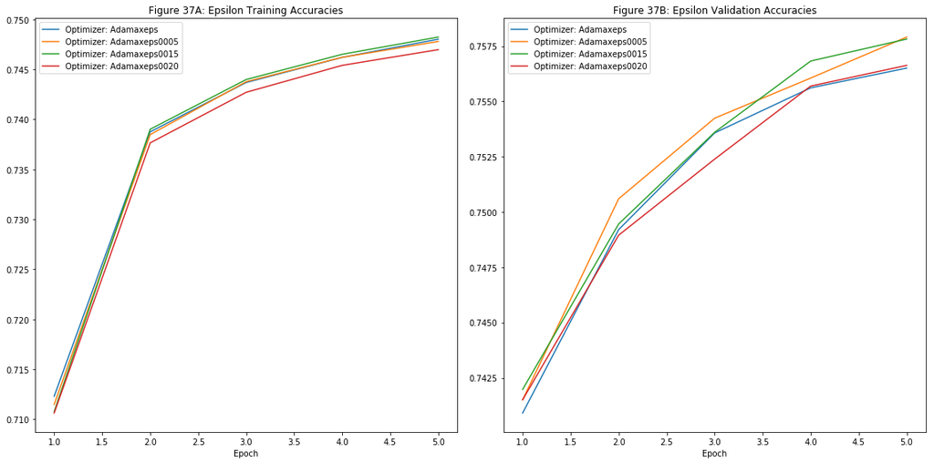

```python
fig, axes = plt.subplots(nrows=1, ncols=2, figsize=(16,8))

pd.DataFrame(trainAcc_eps).plot(title='Figure 37A: Epsilon Training Accuracies', ax=axes[0])
pd.DataFrame(valAcc_eps).plot(title='Figure 37B: Epsilon Validation Accuracies', ax=axes[1])
plt.tight_layout()
```

#### Decay Search

The decay learning rate value of 0 is changed to evaulate if validation accuracy is improved.

```python
hparam = dict(
    units=[best_n_units]*best_n_layers+[1],
    activations=[best_activation]*best_n_layers+['sigmoid'],
    kernel_initializers=best_kernel_initializer
)

optimizers = dict(
    Adamaxde000001=keras.optimizers.Adamax(epsilon=0.000000015,decay=0.000001),
    Adamaxde00001=keras.optimizers.Adamax(epsilon=0.000000015,decay=0.00001),
    Adamaxde0001=keras.optimizers.Adamax(epsilon=0.000000015,decay=0.0001)
)

trainAcc_de = {}
valAcc_de = {}

for optimizer_name in optimizers:
    title = "Optimizer: %s" % optimizer_name
    print(optimizer_name)

    model = net(**hparam, optimizer=optimizers[optimizer_name])
    result = train(model, batch_size=best_batch_size, epochs=5)
    trainAcc_de[title] = result['Train Accuracy']
    valAcc_de[title] = result['Validation Accuracy']
    print("Test Dataset :", get_metrics(y_test, model.predict(x_test)))
```

#### Decay Search Results

The decay in learning rate should still be 0 because the validation accuracy tapers over time [Figure 38].

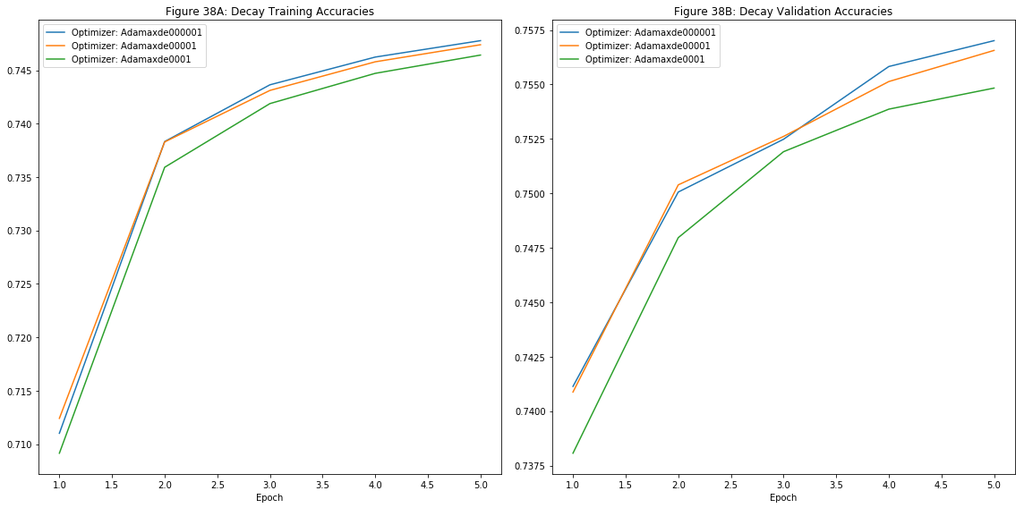

```python
fig, axes = plt.subplots(nrows=1, ncols=2, figsize=(16,8))

pd.DataFrame(trainAcc_de).plot(title='Figure 38A: Decay Training Accuracies', ax=axes[0])
pd.DataFrame(valAcc_de).plot(title='Figure 38B: Decay Validation Accuracies', ax=axes[1])
plt.tight_layout()
```

#### Figure 38: The decay in learning rate should still be 0 because the validation accuracy tapers over time

#### Dropout Search

The drop out rate value of 0.1 is changed to evaulate if validation accuracy is improved.

```python
hparam = dict(
    units=[best_n_units]*best_n_layers+[1],
    activations=[best_activation]*best_n_layers+['sigmoid'],
    kernel_initializers=best_kernel_initializer
)

optimizer = keras.optimizers.Adamax(epsilon=0.000000015)

dropouts = dict(
    dropout1 = 1,
    dropout01 = 0.01,
    dropout001 = 0.001,
    dropout0001 = 0.0001,
    dropout00001 = 0.00001,
    dropout000001 = 0.000001,
    dropout0000001 = 0.0000001,
)

trainAcc_do = {}
valAcc_do = {}

for dropout_name in dropouts:
    title = "Optimizer: %s" % dropout_name
    print(dropout_name)

    model = net(**hparam, optimizer=optimizer, dropouts = dropouts[dropout_name])
    result = train(model, batch_size=best_batch_size, epochs=10)
    trainAcc_do[title] = result['Train Accuracy']
    valAcc_do[title] = result['Validation Accuracy']
    print("Test Dataset :", get_metrics(y_test, model.predict(x_test)))
```

#### Dropout Search Results

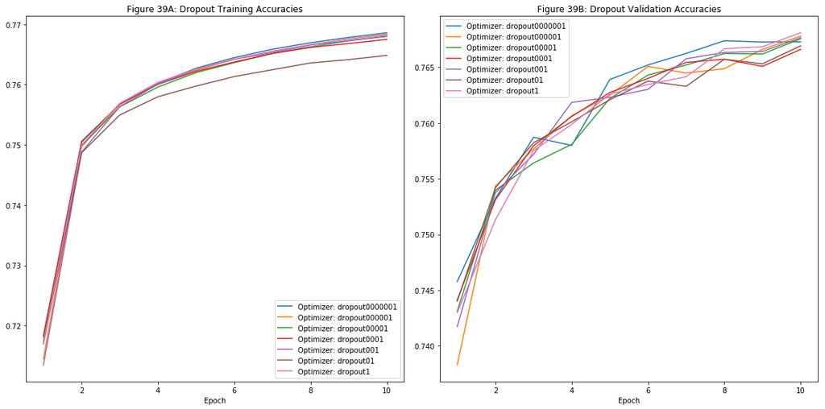

```python
fig, axes = plt.subplots(nrows=1, ncols=2, figsize=(16,8))

pd.DataFrame(trainAcc_do).plot(title='Figure 39A: Dropout Training Accuracies', ax=axes[0])
pd.DataFrame(valAcc_do).plot(title='Figure 39B: Dropout Validation Accuracies', ax=axes[1])
plt.tight_layout()
```

#### Best Shot Parameters

```python
best_n_units = 800

hparam = dict(
    units=[best_n_units]*best_n_layers+[1],
    activations=[best_activation]*best_n_layers+['sigmoid'],
    kernel_initializers=best_kernel_initializer,
    optimizer = keras.optimizers.Adamax(epsilon=0.000000015)
)

dropout = 0.01

model = net(**hparam, dropouts = dropout)
result = train(model, batch_size=best_batch_size, epochs=500, checkpoint=True, patience=5)
print("Test Dataset :", get_metrics(y_test, model.predict(x_test)))
```

#### Best Shot Results

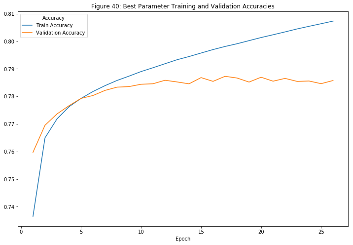

```python
pd.DataFrame(result).plot(figsize=(12,8), title='Figure 40: Best Parameter Training and Validation Accuracies')
plt.show()
```

```python
from sklearn.metrics import roc_auc_score

model = keras.models.load_model('best.h5')
roc_auc_score(y_test,model.predict(x_test))
```

```
0.8719199096956682
```

### Q1: What was the effect of adding more layers/neurons?

Adding neurons adds more capacity to the network and improves the validation accuracy [Figure 31]. The 10% dropout helps with overfitting. There is a big improvement between increasing from 200 neurons to 400 and a small improvement when increasing from 400 neurons to 800. Based on the results, 800 neurons is reasonable where 1000 neurons would overfit the data.

### Q2: Which parameters gave you the best result and why (in your opinion) did they work

Our best parameters is 800 neurons per 3 hidden layers, relu activation, 1000 batch size, random normal initializer, adamax optimizer, epsilon value of 1.5e-8, and a dropout rate of 0.01 [Figure 40]. For neurons and hidden layers, they are optimized because accuracy increased yet decreased once there is overfitting with more neurons and hidden layers.

We have a binary classification problem so we need to have one neuron on the last layer with sigmoid activation and we need to have cross-entropy loss function. Sigmoid and tanh don't work as well on deeper networks as relu because of the vanishing gradients that do not do well for binary classification. Batch size is optimal at 1000 with less overfitting and high accuracy. Initializers for classification perform better with normal distributions rather than uniform distributions because the separation is needed to distinguish the difference, where normal random is the best initializer. The Adamax optimizer is tested best out of the rest of the optimizers. Epsilon of 1.5e-8 is tested to be the best numeric fuzz factor. With increasing the number of neurons in the hidden layers, we rely on a dropout of 0.01 to reduce overfitting. The default Learning Rate of 0.002 and a Decay rate of 0 are tested to be the best hyperparameters.

### Q3: For #6, how did you decide that your model was 'done'

When searching for hyperparameters, we define reasonable hyperparameters search space around the default to tune the parameters. All the hyperparameters are chosen individually based on a grid search yet better hyperparameters could exist if all of the hyperparameters are optimized at the same time. There will always be unexplored combinations of hyperparameters and we cannot claim that we have exhausted the search space. The disadvantages of optimizing everything simultaneously are time and processing allocation.

## References

[1] D. Whiteson, "HIGGS Data Set," UCI Machine Learning Repository, 14-Feb-2014. [Online]. Available: https://archive.ics.uci.edu/ml/datasets/HIGGS [Accessed: 24-July-2018].

[2] P. Baldi, P. Sadowski, and D. Whiteson, "Searching for Exotic Particles in High-energy Physics with Deep Learning," Springer Nature Limited, 2-July-2014. [Online]. Available: https://www.nature.com/articles/ncomms5308 [Accessed: 30-July-2018].

[3] R. Slater, "unit12cs.py," 2DS SMU, [Python Script]. 2018. Class Attachment Download. [Accessed: 24-July-2018].

[4] J. Brownlee, "How to Get Reproducible Results with Keras," Machine Learning Mastery, 14-June-2017. [Online]. Available: https://machinelearningmastery.com/reproducible-results-neural-networks-keras/ [Accessed: 30-July-2018].